# Over-fitting and model selection

## Introduction

In this notebook, we present the problem of over-fitting a model to data. We consider observations generated from noisy observations of the sinus function. We see how polynomial curve fitting is not appropriate when the number of coefficients increases.

## References

- Bishop Christopher M., 1995, Neural networks for pattern recognition. Figure 1.4, page 7

## Overview

For a given function, a *metamodel* is a new function that approximates the initial function. We can name it a *metamodel*, a *surrogate* or a *response surface*.

Tuning a metamodel is to compute its coefficients so that the approximation is as accurate as possible. This is done on a sample. However, if we use the whole sample to train the metamodel, overfitting may happen. This typicall happens when the number of coefficients gets close to the sample size: this is the first topic of this course.

The problem is that, if we use the same sample to train and to test the metamodel, the error we compute is generally low. To overcome this issue, we split the data set in two: the train set and the test set. Once done, we perform the two following steps.

- Training: compute the coefficients on the *train set*.
- Test: check the metamodel on the *test set*.

This is the second topic of this course.

## Define the function

We first define the function.

```python
import openturns as ot
ot.RandomGenerator.SetSeed(0)
```

We define the function that we are going to approximate.

```python
g = ot.SymbolicFunction(['x'], ['sin(2*pi_*x)'])
```

```python
graph = ot.Graph("Polynomial curve fitting","x","y",True,"topright")
# The "unknown" function
curve = g.draw(0,1)
curve.setColors(["green"])
curve.setLegends(["\"Unknown\" function"])
graph.add(curve)
```

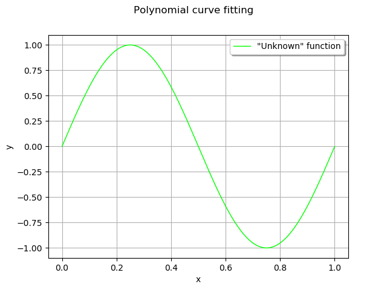

```python
graph
```

This seems a nice, regular, function to approximate with polynomials.

## Create the train set

Then we create the train set.

```python
def linearSample(xmin,xmax,npoints):
    '''Returns a sample created from a regular grid
    from xmin to xmax with npoints points.'''
    step = (xmax-xmin)/(npoints-1)
    rg = ot.RegularGrid(xmin, step, npoints)
    vertices = rg.getVertices()
    return vertices
```

We consider 10 points in the interval [0,1]. Assume that the observations are noisy and that the noise is a gaussian with zero mean and a small standard deviation ($\sigma=0.1)$. The following function computes the observations depending as the sum of the function value and the noise.

```python
def createDataset(n):
    x = linearSample(0,1,n)
    noise = ot.Normal(0,0.1)
    noiseSample = noise.getSample(n)
    y = g(x) + noiseSample
    return x, y
```

The couple (`x_train`,`y_train`) is the training set: it is used to compute the coefficients of the polynomial model.

```python
n_train = 10
x_train, y_train = createDataset(n_train)
```

The following cell plots the polynomial and the observations.

```python
graph = ot.Graph("Polynomial curve fitting","x","y",True,"topright")
# The "unknown" function
curve = g.draw(0,1)
curve.setColors(["green"])
graph.add(curve)
# Training set
cloud = ot.Cloud(x_train,y_train)
cloud.setPointStyle("circle")
cloud.setLegend("Observations")
graph.add(cloud)
```

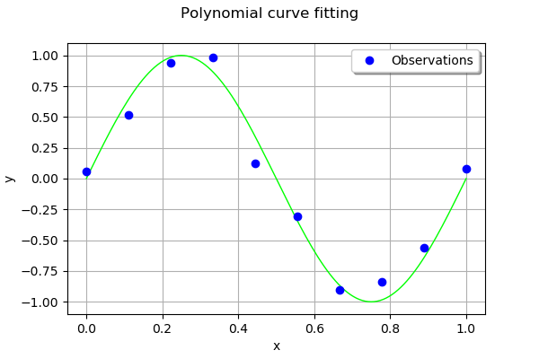

```python
graph
```

We now have 10 observations to compute a metamodel.

## Compute the coefficients of the polynomial decomposition

We want to approximate the function with a polynomial and compute its coefficients with linear least squares.

Let $y\in\mathbb{R}^n$ be a vector of observations.

The polynomial model is $$ P(x) = \beta_0 + \beta_1 x + ... + \beta_p x^p, $$ for any $x\in\mathbb{R}$, where $p$ is the polynomial degree and $\beta\in\mathbb{R}^{p+1}$ is the vector of the coefficients of the model.

Let $n$ be the training sample size and let $x_1,...,x_n\in\mathbb{R}$ be the abscissas of the training set. The design matrix $X\in\mathbb{R}^{n\times (p+1)}$ is $$ x_{i,j} = x^j_i, $$ for $i=1,...,n$ and $j=0,...,p$.

The least squares solution is: $$ \beta^\star = \textrm{argmin}_{\beta\in\mathbb{R}^{p+1}} \|X\beta - y\|_2^2. $$

In order to approximate the function with polynomials up to degree 4, we create a list of strings containing the associated monomials. We do not include a constant in the polynomial basis, as this constant term is automatically included in the model by the `LinearLeastSquares` class. We perform the loop from 1 up to `total_degree` (but the `range` function takes `total_degree+1` as the second input argument).

```python
total_degree = 4
polynomialCollection = ["x^%d" % (degree) for degree in range(1,total_degree+1)]
polynomialCollection
```

```
['x^1', 'x^2', 'x^3', 'x^4']
```

Given the list of strings, we create a symbolic function which computes the values of the monomials.

```python
basis = ot.SymbolicFunction(['x'], polynomialCollection)
basis
```

[x]->[x^1,x^2,x^3,x^4]

The *design matrix* is the matrix involved in the linear least squares problem.

```python
designMatrix = basis(x_train)
designMatrix
```

|  | y0 | y1 | y2 | y3 |
| --- | --- | --- | --- | --- |
| 0 | 0.0 | 0.0 | 0.0 | 0.0 |
| 1 | 0.1111111111111111 | 0.012345679012345678 | 0.0013717421124828531 | 0.00015241579027587256 |
| 2 | 0.2222222222222222 | 0.04938271604938271 | 0.010973936899862825 | 0.002438652644413961 |
| 3 | 0.3333333333333333 | 0.1111111111111111 | 0.037037037037037035 | 0.012345679012345678 |
| 4 | 0.4444444444444444 | 0.19753086419753085 | 0.0877914951989026 | 0.039018442310623375 |
| 5 | 0.5555555555555556 | 0.308641975308642 | 0.1714677640603567 | 0.09525986892242039 |
| 6 | 0.6666666666666666 | 0.4444444444444444 | 0.2962962962962963 | 0.19753086419753085 |
| 7 | 0.7777777777777777 | 0.6049382716049381 | 0.4705075445816184 | 0.3659503124523698 |
| 8 | 0.8888888888888888 | 0.7901234567901234 | 0.7023319615912208 | 0.624295076969974 |
| 9 | 1.0 | 1.0 | 1.0 | 1.0 |

Then we use the `LinearLeastSquares` class to solve the problem, using the design matrix and the output train sample as inputs.

```python
myLeastSquares = ot.LinearLeastSquares(designMatrix, y_train)
myLeastSquares.run()
```

The `getMetaModel` method returns a function, i.e. an operator which has a () operator and returns an output given an input.

```python
responseSurface = myLeastSquares.getMetaModel()
```

## Create the test set

The couple (`x_test`,`y_test`) is the test set: it is used to assess the quality of the polynomial model with points that the training step did not see.

```python
n_test = 50
x_test = linearSample(0,1,n_test)
y_test = responseSurface(basis(x_test))
```

Then we plot the function, the train set and the polynomial.

```python
graph = ot.Graph("Polynomial curve fitting","x","y",True,"topright")
# The "unknown" function
curve = g.draw(0,1)
curve.setColors(["green"])
graph.add(curve)
# Training set
cloud = ot.Cloud(x_train,y_train)
cloud.setPointStyle("circle")
graph.add(cloud)
# Predictions
curve = ot.Curve(x_test,y_test)
curve.setLegend("Polynomial Degree = %d"% (total_degree))
curve.setColor("red")
graph.add(curve)
```

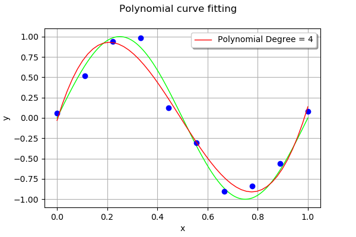

```python
graph
```

We see that the polynomial metamodel approximates the observations well. We now see how to quantify the error.

To see the error, we plot a vertical green line between each observation and its corresponding prediction.

```python
graph = ot.Graph("Least squares minimizes the sum of the squares of the vertical bars","x","y",True,"topright")
# Training set observations
cloud = ot.Cloud(x_train,y_train)
cloud.setPointStyle("circle")
graph.add(cloud)
# Test set
curve = ot.Curve(x_test,y_test)
curve.setLegend("Polynomial Degree = %d"% (total_degree))
curve.setColor("red")
graph.add(curve)
# Errors
ypredicted_train = responseSurface(basis(x_train))
for i in range(n_train):
    curve = ot.Curve([x_train[i],x_train[i]],[y_train[i],ypredicted_train[i]])
    curve.setColor("green")
    curve.setLineWidth(2)
    graph.add(curve)
```

For each observation in the training set, the *residual* is the difference between the model and the observation. The *error* is the absolute value of the residual.

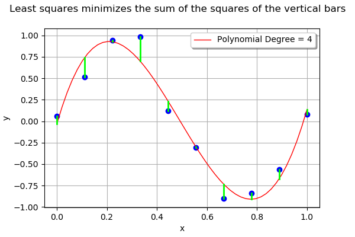

```python
graph
```

The least squares method minimizes the sum of the squared errors i.e. the sum of the squares of the lengths of the vertical segments.

We gather the previous computation in two different functions. The `myPolynomialDataFitting` function computes the least squares solution and `myPolynomialCurveFittingGraph` plots the results.

```python
def myPolynomialDataFitting(total_degree,x_train,y_train):
    '''Computes the polynomial curve fitting
    with given total degree.
    This is for learning purposes only: please consider a serious metamodel
    for real applications, e.g. polynomial chaos or kriging.'''
    polynomialCollection = ["x^%d" % (degree) for degree in range(1,total_degree+1)]
    basis = ot.SymbolicFunction(['x'], polynomialCollection)
    designMatrix = basis(x_train)
    myLeastSquares = ot.LinearLeastSquares(designMatrix, y_train)
    myLeastSquares.run()
    responseSurface = myLeastSquares.getMetaModel()
    return responseSurface, basis
```

```python
def myPolynomialCurveFittingGraph(total_degree,x_train,y_train):
    '''Returns the graphics for a polynomial curve fitting
    with given total degree'''
    responseSurface, basis = myPolynomialDataFitting(total_degree,x_train,y_train)
    # Graphics
    n_test = 100
    x_test = linearSample(0,1,n_test)
    ypredicted_test = responseSurface(basis(x_test))
    # Graphics
    graph = ot.Graph("Polynomial curve fitting","x","y",True,"topright")
    # The "unknown" function
    curve = g.draw(0,1)
    curve.setColors(["green"])
    graph.add(curve)
    # Training set
    cloud = ot.Cloud(x_train,y_train)
    cloud.setPointStyle("circle")
    cloud.setLegend("N=%d" % (x_train.getSize()))
    graph.add(cloud)
    # Predictions
    curve = ot.Curve(x_test,ypredicted_test)
    curve.setLegend("Polynomial Degree = %d"% (total_degree))
    curve.setColor("red")
    graph.add(curve)
    return graph
```

In order to see the effect of the polynomial degree, we compare the polynomial fit with degrees equal to 0 (constant), 1 (linear), 3 (cubic) and 9 (ninic ?).

```python
import pylab as pl
import openturns.viewer
fig = pl.figure(figsize=(12, 9))
_ = fig.suptitle("Polynomial curve fitting")
ax_1 = fig.add_subplot(2, 2, 1)
_ = ot.viewer.View(myPolynomialCurveFittingGraph(0,x_train,y_train), figure=fig, axes=[ax_1])
ax_2 = fig.add_subplot(2, 2, 2)
_ = ot.viewer.View(myPolynomialCurveFittingGraph(1,x_train,y_train), figure=fig, axes=[ax_2])
ax_3 = fig.add_subplot(2, 2, 3)
_ = ot.viewer.View(myPolynomialCurveFittingGraph(3,x_train,y_train), figure=fig, axes=[ax_3])
ax_4 = fig.add_subplot(2, 2, 4)
_ = ot.viewer.View(myPolynomialCurveFittingGraph(9,x_train,y_train), figure=fig, axes=[ax_4]);
pl.close(fig)
```

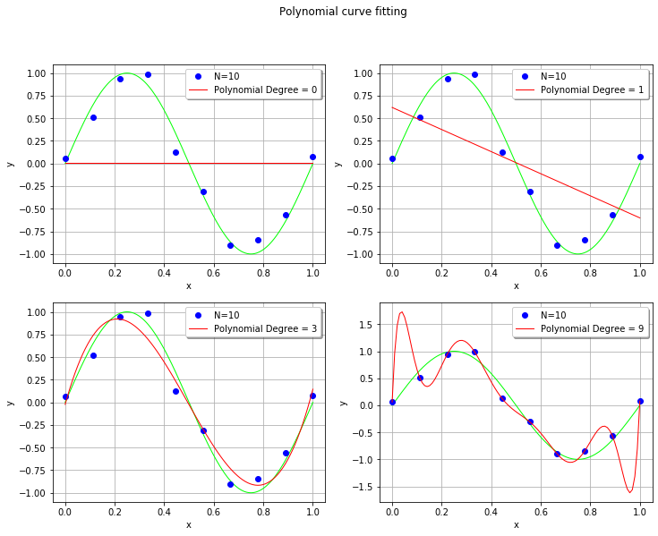

```python
fig
```

However, when the polynomial degree is high, it produces large oscillations which significantly deviate from the true function. This is *overfitting*. This is a pity, given the fact that the polynomial *exactly* interpolates the observations: the residuals are zeroed.

If the locations of the x abscissas could be changed, then the oscillations could be made smaller. This is the method used in gaussian quadrature, where the nodes of interpolation are made closer on the left and right bounds. In our situation, we make the assumption that these abscissas cannot be changed: the most obvious choice is to limit the degree of the polynomial. Another possibility is to include a regularization into the least squares solution.

## Root mean squared error

```python
sqrt = ot.SymbolicFunction(["x"],["sqrt(x)"])
```

First, we create a degree 4 polynomial which fits the data.

```python
total_degree = 4
responseSurface, basis = myPolynomialDataFitting(total_degree,x_train,y_train)
```

Then we create a test set, with the same method as before.

```python
n_test = 100
x_test, y_test = createDataset(n_test)
```

On this test set, we evaluate the polynomial.

```python
ypredicted_test = responseSurface(basis(x_test))
```

The vector of residuals is the vector of the differences between the observations and the predictions.

```python
residuals = y_test.asPoint() - ypredicted_test.asPoint()
```

The `normSquare` method computes the square of the Euclidian norm (i.e. the 2-norm). We divide this by the test sample size (so as to compare the error for different sample sizes) and compute the square root of the result (so that the result has the same unit as y).

```python
RMSE = sqrt([residuals.normSquare()/n_test])[0]
RMSE
```

```
0.14464766752910913
```

The following function gathers the RMSE computation to make the experiment easier.

```python
def computeRMSE(responseSurface, basis, x, y):
    ypredicted = responseSurface(basis(x))
    residuals = y.asPoint() - ypredicted.asPoint()
    RMSE = sqrt([residuals.normSquare()/n_test])[0]
    return RMSE
```

For each degree from 0 to 9, we compute the RMSE computed from the train set and from the test set.

```python
maximum_degree = 10
RMSE_train = ot.Sample(maximum_degree,1)
RMSE_test = ot.Sample(maximum_degree,1)
for total_degree in range(maximum_degree):
    responseSurface, basis = myPolynomialDataFitting(total_degree,x_train,y_train)
    RMSE_train[total_degree,0] = computeRMSE(responseSurface, basis, x_train, y_train)
    RMSE_test[total_degree,0] = computeRMSE(responseSurface, basis, x_test, y_test)
```

Then we create a graphics to compare the RMSE from the train and test sets.

```python
degreeSample = ot.Sample(range(maximum_degree),1)
graph = ot.Graph("Root mean square error","Degree","RMSE",True,"topright")
# Train
cloud = ot.Curve(degreeSample,RMSE_train)
cloud.setColor("blue")
cloud.setLegend("Train")
cloud.setPointStyle("circle")
graph.add(cloud)
# Test
cloud = ot.Curve(degreeSample,RMSE_test)
cloud.setColor("red")
cloud.setLegend("Test")
cloud.setPointStyle("circle")
graph.add(cloud);
```

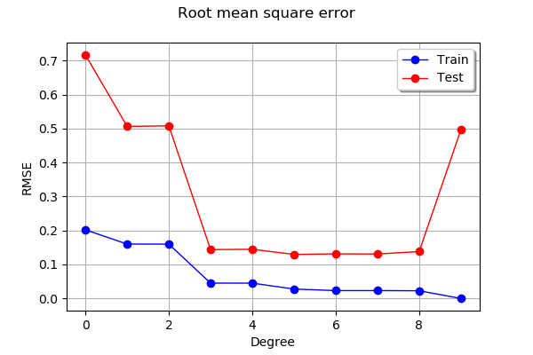

```python
graph
```

We see that the RMSE on the train set continuously decreases, reaching zero when the polynomial degree is so that the number of coefficients is equal to the train dataset sample size. In this extreme situation, the least squares solution is equivalent to solving a linear system of equations: this leads to a zero residual.

On the test set however, the RMSE decreases, reaches a flat region, then increases dramatically when the degree is equal to 9. Hence, limiting the polynomial degree limits overfitting.

## Increasing the training set

We wonder what happens when the training dataset size is increased.

```python
total_degree = 9
fig = pl.figure(figsize=(12, 9))
_ = fig.suptitle("Polynomial curve fitting")
#
ax_1 = fig.add_subplot(2, 2, 1)
n_train = 11
x_train, y_train = createDataset(n_train)
_ = ot.viewer.View(myPolynomialCurveFittingGraph(total_degree,x_train,y_train), figure=fig, axes=[ax_1])
#
n_train = 100
x_train, y_train = createDataset(n_train)
ax_2 = fig.add_subplot(2, 2, 2)
_ = ot.viewer.View(myPolynomialCurveFittingGraph(total_degree,x_train,y_train), figure=fig, axes=[ax_2])
pl.close(fig)
```

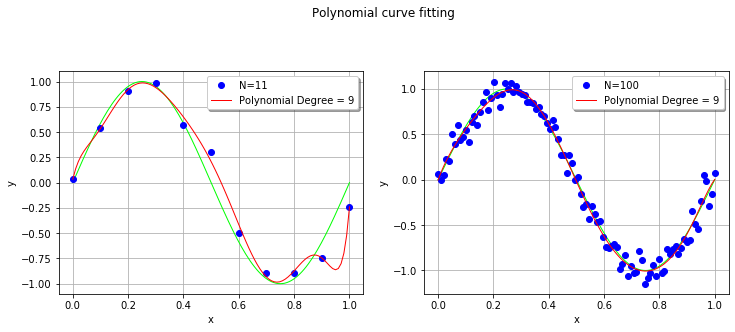

```python
fig
```

We see that the polynomial oscillates with a dataset with size 11, but does not with the larger dataset: increasing the training dataset mitigates the oscillations.

## Conclusion

When the number of coefficients in a metamodel gets closer to the training set sample size, overfitting may occur. This is why we generally limit the ratio between the number of coefficients and the sample size: the lower, the better.